# mod1_mcspadden-diana

Diana McSpadden (hdm5s)

2/2/2021

# Module 1 Homework

## H. Diana McSpadden (hdm5s)

Complete exercises 1, 2, 6, 8, and 10 at the end of Chapter 2 of your textbook. Attempt each of these exercises prior to the live session since they will likely serve as material for discussion and interaction.

## Exercise 1

For each of parts (a) through (d), indicate whether we would generally expect the performance of a flexible statistical learning method to be better or worse than an inflexible method. Justify your answer.

#### (a) The sample size n is extremely large, and the number of predictors p is small.

ANSWER: **Inflexible**, this is an ideal regression data set if there is a linear relationship, or if the parameters can be tranformed to allow the linear assumptions to be met. We can possibly create an accurate model that is also interpretable.

#### (b) The number of predictors p is extremely large, and the number of observations n is small.

ANSWER: **Inflexible** or **Flexible**, I could recommend two different approaches: lasso method if the n is large enough and we want to select which of the parameters are most useful. Lasso will help with feature selection. However, if n is really really small and we cannot get the n:p ratio large enough using lasso, then a flexible method such a a support vector machine is recommended.

#### (c) The relationship between the predictors and response is highly non-linear.

ANSWER: **Flexible** because highly non-linear function decision boundaries require flexible approaches.

#### (d) The variance of the error terms, i.e. σ2 = Var(E), is extremely high.

ANSWER: This scenario requires a **flexible** method. Standard variance is an assumption for inflexible methods.

## Exercise 2

Explain whether each scenario is a classification or regression problem, and indicate whether we are most interested in inference or prediction. Finally, provide n and p.

#### (a) We collect a set of data on the top 500 firms in the US…

For each firm we record profit, number of employees, industry and the CEO salary. We are interested in understanding which factors affect CEO salary.

**ANSWER:**

This scenario is a **regression** problem specifically interested in determining **inference**, so an interpretable model is important. A regression solution will provide the coefficients for each parameter which allow comparison of parameter influence on CEO salary. n = 500, p = 3.

#### (b) We are considering launching a new product and wish to know whether it will be a success or a failure…

We collect data on 20 similar products that were previously launched. For each product we have recorded whether it was a success or failure, price charged for the product, marketing budget, competition price, and ten other variables.

**ANSWER:**

This is a **categorization** problem with “success” or “failure” categories. In this scenario we are interested in **predicting** whether our new product will succeed or fail. n = 20, p = 13.

#### (c) We are interest in predicting the % change in the USD/Euro

**ANSWER:**

**Regression**, we are trying to **predict** a continuous value, not a condition. n = number of changes in USD/Euro in our data set. p = parameters in our data that we believe predict USD/Euro currency rate change.

## Exercise 6:

Describe the differences between a parametric and a non-parametric statistical learning approach. What are the advantages of a parametric approach to regression or classification (as opposed to a nonparametric approach)? What are its disadvantages?

**ANSWER:**

Parametric approaches assume the shape of the function will be a specific shape/form. The advantage of a parametric approach is that it simplifies the fitting problem to estimating coefficients in the function, typically by reducing squared error from the mean, while keeping the specific form. THe downside to assuming the form of the function is that the estimated function could be far from the true form. However, parametric approaches are more simple to understand and implement that non-parametric methods.

Non-parametric approaches assume no such restrictions on the model’s form, and thus try to map to the data points as closely as possible while minimizing variance (as configured). Non-parametric approaches require a large number of observations in order to limit over-fitting. Non-parametric approaches can also introduce additional bias, but if bias and over-fitting are controlled they may provide a better estimation of the function.

## Execise 8

This exercise relates to the College data set, which can be found in the file College.csv.

…

### (a) Use the read.csv() function to read the data into R.

Call the loaded data college. Make sure that you have the directory set to the correct location for the data.

```r
college <- read.csv("College.csv")
head(college)
```

```
##                              X Private Apps Accept Enroll Top10perc Top25perc
## 1 Abilene Christian University     Yes 1660   1232    721        23        52
## 2           Adelphi University     Yes 2186   1924    512        16        29
## 3               Adrian College     Yes 1428   1097    336        22        50
## 4          Agnes Scott College     Yes  417    349    137        60        89
## 5    Alaska Pacific University     Yes  193    146     55        16        44
## 6            Albertson College     Yes  587    479    158        38        62
##   F.Undergrad P.Undergrad Outstate Room.Board Books Personal PhD Terminal
## 1        2885         537     7440       3300   450     2200  70       78
## 2        2683        1227    12280       6450   750     1500  29       30
## 3        1036          99    11250       3750   400     1165  53       66
## 4         510          63    12960       5450   450      875  92       97
## 5         249         869     7560       4120   800     1500  76       72
## 6         678          41    13500       3335   500      675  67       73
##   S.F.Ratio perc.alumni Expend Grad.Rate
## 1      18.1          12   7041        60
## 2      12.2          16  10527        56
## 3      12.9          30   8735        54
## 4       7.7          37  19016        59
## 5      11.9           2  10922        15
## 6       9.4          11   9727        55
```

### (b) fix() …

```r
rownames(college) = college[,1] # first column is the name of the university
#fix (college) #fix pops up a "fix" form to edit the data
```

```r
college =college [,-1] #remove the first column
#fix (college )
```

### (c) summary() and plotting

#### i: Use the summary() function

```r
summary(college) # display summary statistics and data information
```

```
##    Private               Apps           Accept          Enroll
##  Length:777         Min.   :   81   Min.   :   72   Min.   :  35
##  Class :character   1st Qu.:  776   1st Qu.:  604   1st Qu.: 242
##  Mode  :character   Median : 1558   Median : 1110   Median : 434
##                     Mean   : 3002   Mean   : 2019   Mean   : 780
##                     3rd Qu.: 3624   3rd Qu.: 2424   3rd Qu.: 902
##                     Max.   :48094   Max.   :26330   Max.   :6392
##    Top10perc       Top25perc      F.Undergrad     P.Undergrad
##  Min.   : 1.00   Min.   :  9.0   Min.   :  139   Min.   :    1.0
##  1st Qu.:15.00   1st Qu.: 41.0   1st Qu.:  992   1st Qu.:   95.0
##  Median :23.00   Median : 54.0   Median : 1707   Median :  353.0
##  Mean   :27.56   Mean   : 55.8   Mean   : 3700   Mean   :  855.3
##  3rd Qu.:35.00   3rd Qu.: 69.0   3rd Qu.: 4005   3rd Qu.:  967.0
##  Max.   :96.00   Max.   :100.0   Max.   :31643   Max.   :21836.0
##     Outstate       Room.Board       Books           Personal
##  Min.   : 2340   Min.   :1780   Min.   :  96.0   Min.   : 250
##  1st Qu.: 7320   1st Qu.:3597   1st Qu.: 470.0   1st Qu.: 850
##  Median : 9990   Median :4200   Median : 500.0   Median :1200
##  Mean   :10441   Mean   :4358   Mean   : 549.4   Mean   :1341
##  3rd Qu.:12925   3rd Qu.:5050   3rd Qu.: 600.0   3rd Qu.:1700
##  Max.   :21700   Max.   :8124   Max.   :2340.0   Max.   :6800
##       PhD            Terminal       S.F.Ratio      perc.alumni
##  Min.   :  8.00   Min.   : 24.0   Min.   : 2.50   Min.   : 0.00
##  1st Qu.: 62.00   1st Qu.: 71.0   1st Qu.:11.50   1st Qu.:13.00
##  Median : 75.00   Median : 82.0   Median :13.60   Median :21.00
##  Mean   : 72.66   Mean   : 79.7   Mean   :14.09   Mean   :22.74
##  3rd Qu.: 85.00   3rd Qu.: 92.0   3rd Qu.:16.50   3rd Qu.:31.00
##  Max.   :103.00   Max.   :100.0   Max.   :39.80   Max.   :64.00
##      Expend        Grad.Rate
##  Min.   : 3186   Min.   : 10.00
##  1st Qu.: 6751   1st Qu.: 53.00
##  Median : 8377   Median : 65.00
##  Mean   : 9660   Mean   : 65.46
##  3rd Qu.:10830   3rd Qu.: 78.00
##  Max.   :56233   Max.   :118.00
```

#### ii. Use the pairs() function

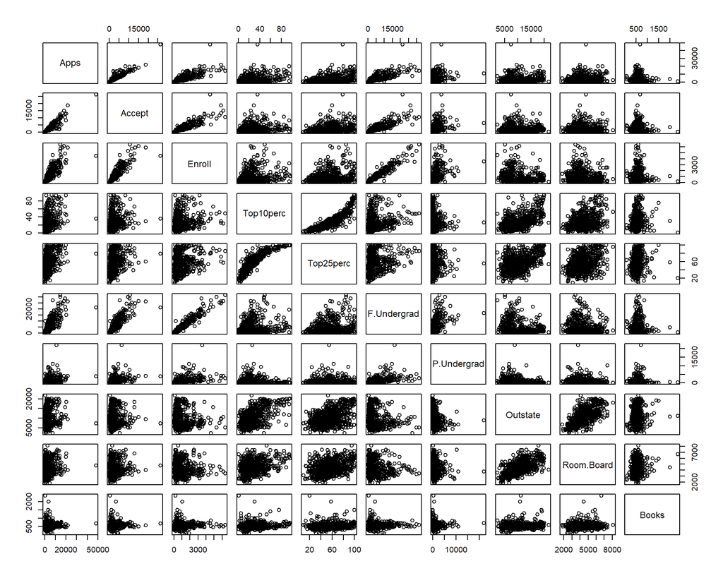

```r
#?pairs
pairs(college[,2:11])
```

#### iii. plot() function

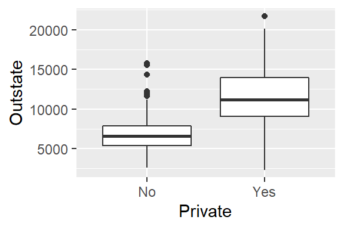

```r
# plot side by side boxplots of Outstate versus Private (Private universities have more out of state students):
#boxplot(college$Outstate~college$Private) # base R

# ggplot
ggplot(college, aes(x=Private, y=Outstate)) +
  geom_boxplot()
```

#### iv. Create a new qualitative variable, called Elite, …

by binning the Top10perc variable. We are going to divide universities into two groups based on whether or not the proportion of students coming from the top 10% of their high school classes exceeds 50%.

```r
#?rep
Elite = rep("No",nrow(college )) # replicates the values in x.

Elite[college$Top10perc > 50]=" Yes" #for indexes where top 10% is above 50%, set Elite to "Yes"

Elite = as.factor (Elite) # set Elite as a factor Yes/No

college = data.frame(college ,Elite) # append the new Elite column to the college dataframe
```

```r
head(college) # show with new Elite column
```

```
##                              Private Apps Accept Enroll Top10perc Top25perc
## Abilene Christian University     Yes 1660   1232    721        23        52
## Adelphi University               Yes 2186   1924    512        16        29
## Adrian College                   Yes 1428   1097    336        22        50
## Agnes Scott College              Yes  417    349    137        60        89
## Alaska Pacific University        Yes  193    146     55        16        44
## Albertson College                Yes  587    479    158        38        62
##                              F.Undergrad P.Undergrad Outstate Room.Board Books
## Abilene Christian University        2885         537     7440       3300   450
## Adelphi University                  2683        1227    12280       6450   750
## Adrian College                      1036          99    11250       3750   400
## Agnes Scott College                  510          63    12960       5450   450
## Alaska Pacific University            249         869     7560       4120   800
## Albertson College                    678          41    13500       3335   500
##                              Personal PhD Terminal S.F.Ratio perc.alumni Expend
## Abilene Christian University     2200  70       78      18.1          12   7041
## Adelphi University               1500  29       30      12.2          16  10527
## Adrian College                   1165  53       66      12.9          30   8735
## Agnes Scott College               875  92       97       7.7          37  19016
## Alaska Pacific University        1500  76       72      11.9           2  10922
## Albertson College                 675  67       73       9.4          11   9727
##                              Grad.Rate Elite
## Abilene Christian University        60    No
## Adelphi University                  56    No
## Adrian College                      54    No
## Agnes Scott College                 59   Yes
## Alaska Pacific University           15    No
## Albertson College                   55    No
```

```r
summary(college)
```

```
##    Private               Apps           Accept          Enroll
##  Length:777         Min.   :   81   Min.   :   72   Min.   :  35
##  Class :character   1st Qu.:  776   1st Qu.:  604   1st Qu.: 242
##  Mode  :character   Median : 1558   Median : 1110   Median : 434
##                     Mean   : 3002   Mean   : 2019   Mean   : 780
##                     3rd Qu.: 3624   3rd Qu.: 2424   3rd Qu.: 902
##                     Max.   :48094   Max.   :26330   Max.   :6392
##    Top10perc       Top25perc      F.Undergrad     P.Undergrad
##  Min.   : 1.00   Min.   :  9.0   Min.   :  139   Min.   :    1.0
##  1st Qu.:15.00   1st Qu.: 41.0   1st Qu.:  992   1st Qu.:   95.0
##  Median :23.00   Median : 54.0   Median : 1707   Median :  353.0
##  Mean   :27.56   Mean   : 55.8   Mean   : 3700   Mean   :  855.3
##  3rd Qu.:35.00   3rd Qu.: 69.0   3rd Qu.: 4005   3rd Qu.:  967.0
##  Max.   :96.00   Max.   :100.0   Max.   :31643   Max.   :21836.0
##     Outstate       Room.Board       Books           Personal
##  Min.   : 2340   Min.   :1780   Min.   :  96.0   Min.   : 250
##  1st Qu.: 7320   1st Qu.:3597   1st Qu.: 470.0   1st Qu.: 850
##  Median : 9990   Median :4200   Median : 500.0   Median :1200
##  Mean   :10441   Mean   :4358   Mean   : 549.4   Mean   :1341
##  3rd Qu.:12925   3rd Qu.:5050   3rd Qu.: 600.0   3rd Qu.:1700
##  Max.   :21700   Max.   :8124   Max.   :2340.0   Max.   :6800
##       PhD            Terminal       S.F.Ratio      perc.alumni
##  Min.   :  8.00   Min.   : 24.0   Min.   : 2.50   Min.   : 0.00
##  1st Qu.: 62.00   1st Qu.: 71.0   1st Qu.:11.50   1st Qu.:13.00
##  Median : 75.00   Median : 82.0   Median :13.60   Median :21.00
##  Mean   : 72.66   Mean   : 79.7   Mean   :14.09   Mean   :22.74
##  3rd Qu.: 85.00   3rd Qu.: 92.0   3rd Qu.:16.50   3rd Qu.:31.00
##  Max.   :103.00   Max.   :100.0   Max.   :39.80   Max.   :64.00
##      Expend        Grad.Rate       Elite
##  Min.   : 3186   Min.   : 10.00    Yes: 78
##  1st Qu.: 6751   1st Qu.: 53.00   No  :699
##  Median : 8377   Median : 65.00
##  Mean   : 9660   Mean   : 65.46
##  3rd Qu.:10830   3rd Qu.: 78.00
##  Max.   :56233   Max.   :118.00
```

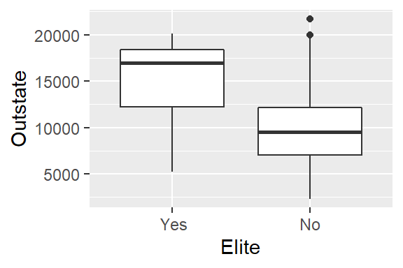

```r
#boxplot(college$Outstate~college$Elite) # base R

# ggplot
ggplot(college, aes(x=Elite, y=Outstate)) +
  geom_boxplot()
```

#### v. Use the hist() function to produce some histograms with differing numbers of bins for a few of the quantitative variables.

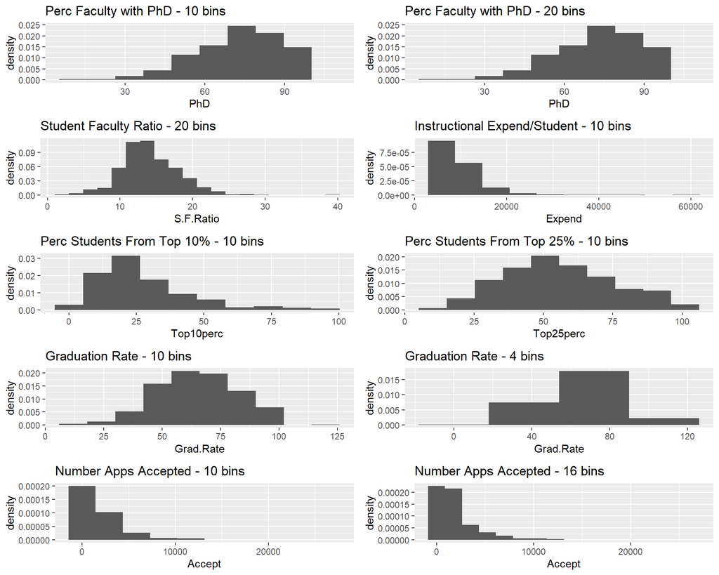

```r
#hist(college$PhD, breaks=10, main="Perc Faculty with PhD - 10 bins") # base R

plot1 <- ggplot(college, aes(x = PhD, y = stat(density))) +
  geom_histogram(bins=10) +
  ggtitle("Perc Faculty with PhD - 10 bins")

plot2 <- ggplot(college, aes(x = PhD, y = stat(density))) +
  geom_histogram(bins=10) +
  ggtitle("Perc Faculty with PhD - 20 bins")

plot3 <- ggplot(college, aes(x = S.F.Ratio, y = stat(density))) +
  geom_histogram(bins=20) +
  ggtitle("Student Faculty Ratio - 20 bins")

plot4 <- ggplot(college, aes(x = Expend, y = stat(density))) +
  geom_histogram(bins=10) +
  ggtitle("Instructional Expend/Student - 10 bins")

plot5 <- ggplot(college, aes(x = Top10perc, y = stat(density))) +
  geom_histogram(bins=10) +
  ggtitle("Perc Students From Top 10% - 10 bins")

plot6 <- ggplot(college, aes(x = Top25perc, y = stat(density))) +
  geom_histogram(bins=10) +
  ggtitle("Perc Students From Top 25% - 10 bins")

plot7 <- ggplot(college, aes(x = Grad.Rate, y = stat(density))) +
  geom_histogram(bins=10) +
  ggtitle("Graduation Rate - 10 bins")

plot8 <- ggplot(college, aes(x = Grad.Rate, y = stat(density))) +
  geom_histogram(bins = 4) +
  ggtitle("Graduation Rate - 4 bins")

plot9 <- ggplot(college, aes(x = Accept, y = stat(density))) +
  geom_histogram(bins = 10) +
  ggtitle("Number Apps Accepted - 10 bins")

plot10 <- ggplot(college, aes(x = Accept, y = stat(density))) +
  geom_histogram(bins = 16) +
  ggtitle("Number Apps Accepted - 16 bins")

grid.arrange(plot1, plot2, plot3, plot4, plot5, plot6, plot7, plot8, plot9, plot10, nrow=5)
```

#### v. Continue exploring the data, and provide a brief summary of what you discover.

```r
# scale/normalize the data
college_standardized <- as.data.frame(scale(select(college, -c(Private,Elite))))
head(college_standardized)
```

```
##                                    Apps      Accept      Enroll  Top10perc
## Abilene Christian University -0.3466585 -0.32099869 -0.06346802 -0.2584163
## Adelphi University           -0.2107483 -0.03867808 -0.28839845 -0.6552335
## Adrian College               -0.4066037 -0.37607569 -0.47781355 -0.3151045
## Agnes Scott College          -0.6678304 -0.68124306 -0.69198176  1.8390460
## Alaska Pacific University    -0.7257086 -0.76406254 -0.78023197 -0.6552335
## Albertson College            -0.6239051 -0.62820595 -0.66938109  0.5919062
##                               Top25perc F.Undergrad P.Undergrad   Outstate
## Abilene Christian University -0.1917039  -0.1680076 -0.20907246 -0.7458755
## Adelphi University           -1.3530399  -0.2096534  0.24414978  0.4572019
## Adrian College               -0.2926897  -0.5492116 -0.49677006  0.2011751
## Agnes Scott College           1.6765321  -0.6576558 -0.52041644  0.6262293
## Alaska Pacific University    -0.5956469  -0.7114656  0.00899969 -0.7160471
## Albertson College             0.3132247  -0.6230197 -0.53486701  0.7604569
##                              Room.Board      Books   Personal        PhD
## Abilene Christian University -0.9642836 -0.6019244  1.2692276 -0.1629230
## Adelphi University            1.9079789  1.2150971  0.2353633 -2.6739232
## Adrian College               -0.5539604 -0.9047614 -0.2594146 -1.2040694
## Agnes Scott College           0.9961495 -0.6019244 -0.6877298  1.1844430
## Alaska Pacific University    -0.2165835  1.5179340  0.2353633  0.2045405
## Albertson College            -0.9323696 -0.2990875 -0.9831196 -0.3466547
##                                Terminal  S.F.Ratio perc.alumni      Expend
## Abilene Christian University -0.1156542  1.0131234  -0.8670157 -0.50158700
## Adelphi University           -3.3760014 -0.4773970  -0.5442217  0.16600292
## Adrian College               -0.9307410 -0.3005556   0.5855576 -0.17717583
## Agnes Scott College           1.1748999 -1.6142346   1.1504472  1.79169738
## Alaska Pacific University    -0.5231976 -0.5531862  -1.6740009  0.24164779
## Albertson College            -0.4552737 -1.1847626  -0.9477142  0.01279812
##                               Grad.Rate
## Abilene Christian University -0.3180471
## Adelphi University           -0.5509070
## Adrian College               -0.6673369
## Agnes Scott College          -0.3762621
## Alaska Pacific University    -2.9377211
## Albertson College            -0.6091220
```

**Visualize the scaled data for a few fields

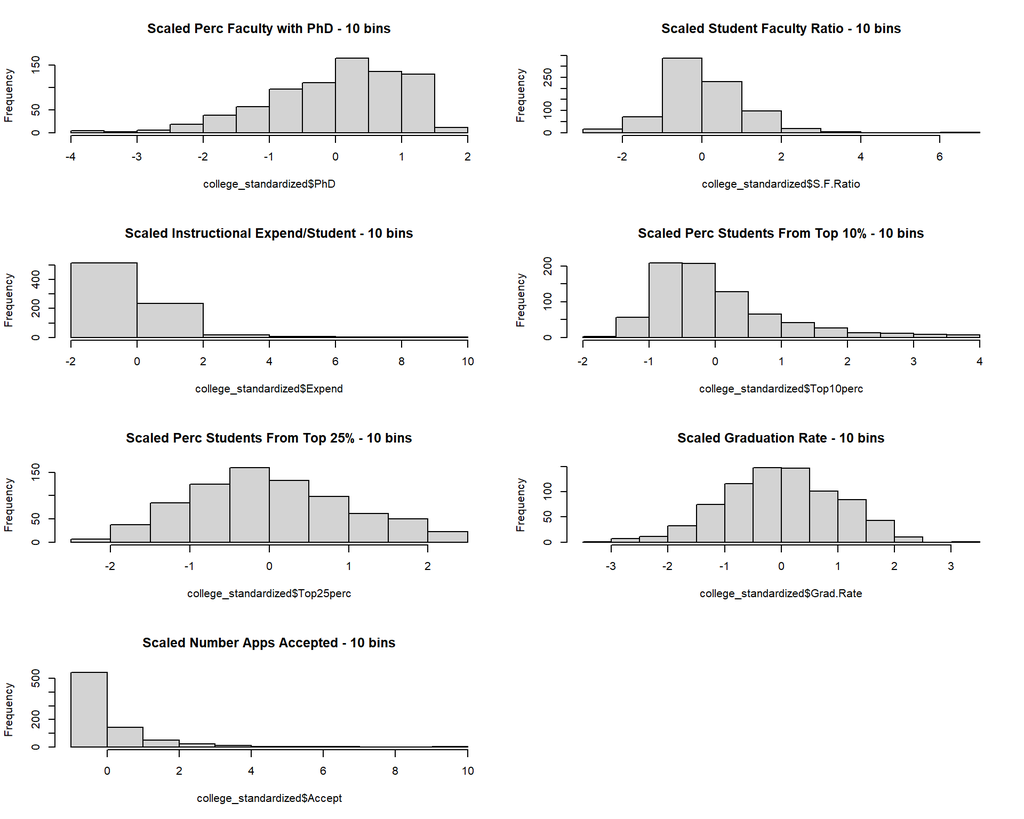

```r
# these are all Base R plots
par(mfrow=c(4,2))

hist(college_standardized$PhD, breaks=10, main="Scaled Perc Faculty with PhD - 10 bins")

hist(college_standardized$S.F.Ratio, breaks=10, main="Scaled Student Faculty Ratio - 10 bins")

hist(college_standardized$Expend, breaks=5, main="Scaled Instructional Expend/Student - 10 bins")

hist(college_standardized$Top10perc, breaks=10, main="Scaled Perc Students From Top 10% - 10 bins")

hist(college_standardized$Top25perc, breaks=10, main="Scaled Perc Students From Top 25% - 10 bins")

hist(college_standardized$Grad.Rate, breaks=10, main="Scaled Graduation Rate - 10 bins")

hist(college_standardized$Accept, breaks=10, main="Scaled Number Apps Accepted - 10 bins")
```

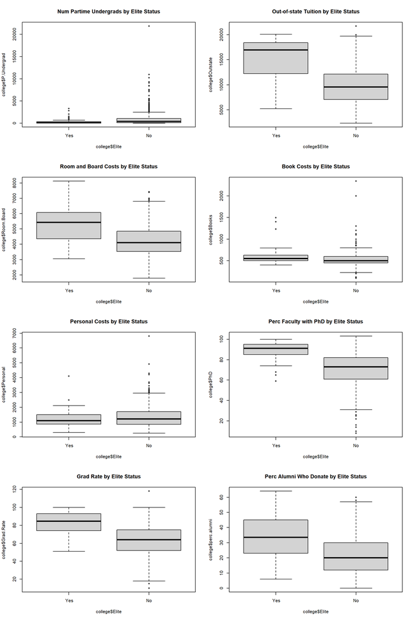

```r
# these are all Base R plots
par(mfrow=c(4,2))

boxplot(college$P.Undergrad~college$Elite, main='Num Partime Undergrads by Elite Status')

boxplot(college$Outstate~college$Elite, main='Out-of-state Tuition by Elite Status')

boxplot(college$Room.Board~college$Elite, main='Room and Board Costs by Elite Status')

boxplot(college$Books~college$Elite, main='Book Costs by Elite Status')

boxplot(college$Personal~college$Elite, main='Personal Costs by Elite Status')

boxplot(college$PhD~college$Elite, main='Perc Faculty with PhD by Elite Status')

boxplot(college$Grad.Rate~college$Elite, main='Grad Rate by Elite Status')

boxplot(college$perc.alumni~college$Elite, main='Perc Alumni Who Donate by Elite Status')
```

**Interesting Findings**

1. Graduation Rate and Top25 Perc, have normal distributions across the colleges in the sample
2. Across our sample, “Elite Colleges”, defined by high school grads in top 10% of class make up 50% of admissions, have:
- higher graduation rates
- greater perc of alumni who donate
- higher perc of faculty with PhD’s
- higher room and board costs
- and higher out-of-state tuition
3. However, Elite Colleges have similar:
- book costs
- estimated personal spending
- and perc of part-time undergradutes

## Exercise 10

This exercise involves the Boston housing data set.

### (a) load in the Boston data set.

```r
library(MASS)
#?Boston
dim(Boston)
```

```
## [1] 506  14
```

The Boston data frame has 506 rows and 14 columns.

1. crim: per capita crime rate by town.
2. zn: proportion of residential land zoned for lots over 25,000 sq.ft.
3. indus: proportion of non-retail business acres per town.
4. chas: Charles River dummy variable (= 1 if tract bounds river; 0 otherwise).
5. nox: nitrogen oxides concentration (parts per 10 million).
6. rm: average number of rooms per dwelling.
7. age: proportion of owner-occupied units built prior to 1940.
8. dis: weighted mean of distances to five Boston employment centres.
9. rad: index of accessibility to radial highways.
10. tax: full-value property-tax rate per $10,000.
11. ptratio: pupil-teacher ratio by town.
12. black: 1000(Bk - 0.63)^2 where Bk is the proportion of blacks by town.
13. lstat: lower status of the population (percent).
14. medv: median value of owner-occupied homes in $1000s.

**ANSWER:** There are 506 rows and 14 columns in the Boston dataframe.

```r
head(Boston)
```

```
##      crim zn indus chas   nox    rm  age    dis rad tax ptratio  black lstat
## 1 0.00632 18  2.31    0 0.538 6.575 65.2 4.0900   1 296    15.3 396.90  4.98
## 2 0.02731  0  7.07    0 0.469 6.421 78.9 4.9671   2 242    17.8 396.90  9.14
## 3 0.02729  0  7.07    0 0.469 7.185 61.1 4.9671   2 242    17.8 392.83  4.03
## 4 0.03237  0  2.18    0 0.458 6.998 45.8 6.0622   3 222    18.7 394.63  2.94
## 5 0.06905  0  2.18    0 0.458 7.147 54.2 6.0622   3 222    18.7 396.90  5.33
## 6 0.02985  0  2.18    0 0.458 6.430 58.7 6.0622   3 222    18.7 394.12  5.21
##   medv
## 1 24.0
## 2 21.6
## 3 34.7
## 4 33.4
## 5 36.2
## 6 28.7
```

### (b) Make some pairwise scatterplots …

of the predictors (columns) in this data set. Describe your findings.

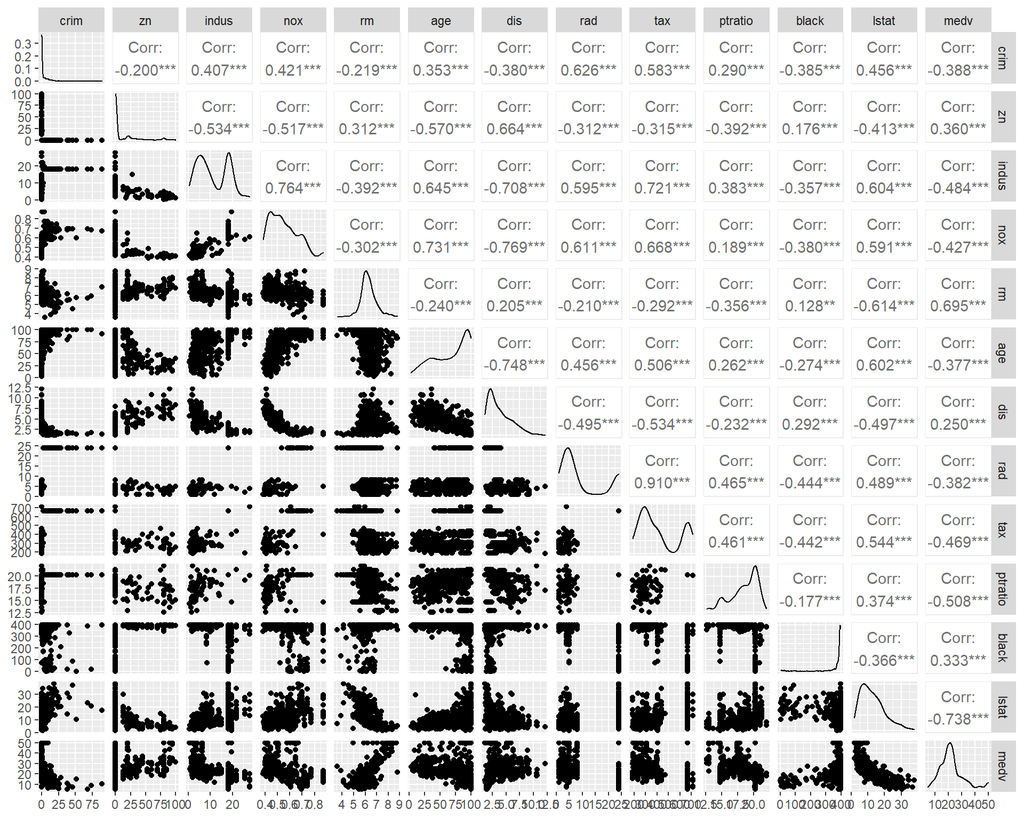

```r
#pairs(Boston[-4], main='Boston Crime data') # Base R version

ggpairs(Boston[-4], lower = list(continuous = "points", combo = "dot_no_facet"), progress = F)
```

**ANSWER** There are positive crime correlations of note with:

- indus: proportion of non-retail business acres per town.
- age: proportion of owner-occupied units built prior to 1940
- lstat: lower status of the population (percent)
- rad: index of accessibility to radial highways - highest correlation
- tax: full-value property-tax rate per $10,000

There are negative crime correlations of note with:

- dis: weighted mean of distances to five Boston employment centres
- medv: median value of owner-occupied homes in $1000s
- black: 1000(Bk - 0.63)^2 where Bk is the proportion of blacks by town

The strongest correlations in the data set are between:

- Positive correlation between **tax** and **rad**, i.e. greater tax rate as accessibility to radial highways increases
- Negative correlation between **medv** and **lstat**, and the lower status of the population increases the median value of homes decreases
- Negative correlation between **dist** and **nox** and **indus**, i.e. as the weighted mean of distances to five Boston employment centres increases the nitrogen oxides concentration decreases, and the proportion of non-retail business acres per town decreases.
- Postive correlation between **age** and **nox**, i.e. as the proportion of owner-occupied units built prior to 1940 increases the nitrogen oxides concentration increases

### (c) Are any of the predictors associated with per capita crime rate?

If so, explain the relationship.

**ANSWER**:

Two predictors have correlation of note with the per capita crime rate:

- Positive correlation with rad: index of accessibility to radial highways - highest correlation
- Positive correlation with tax: full-value property-tax rate per $10,000

### (d) Do any of the suburbs of Boston appear to have …

- particularly high crime rates?
- Tax rates?
- Pupil-teacher ratios?

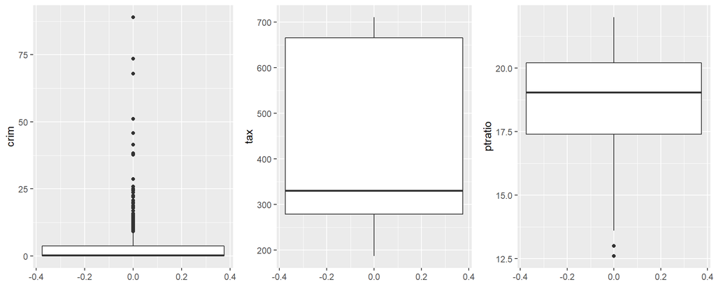

```r
plot1 <- ggplot(Boston, aes(y=crim)) +
  geom_boxplot()

plot2 <- ggplot(Boston, aes(y=tax)) +
  geom_boxplot()

plot3 <- ggplot(Boston, aes(y=ptratio)) +
  geom_boxplot()

grid.arrange(plot1, plot2, plot3, nrow=1)
```

```r
print(summary(Boston[1]))
```

```
##       crim
##  Min.   : 0.00632
##  1st Qu.: 0.08205
##  Median : 0.25651
##  Mean   : 3.61352
##  3rd Qu.: 3.67708
##  Max.   :88.97620
```

```r
print(summary(Boston[10]))
```

```
##       tax
##  Min.   :187.0
##  1st Qu.:279.0
##  Median :330.0
##  Mean   :408.2
##  3rd Qu.:666.0
##  Max.   :711.0
```

```r
print(summary(Boston[11]))
```

```
##     ptratio
##  Min.   :12.60
##  1st Qu.:17.40
##  Median :19.05
##  Mean   :18.46
##  3rd Qu.:20.20
##  Max.   :22.00
```

Comment on the range of each predictor.

**ANSWER**

There are many **outliers for high crime per capita**. One can see this represented in the box plot, and it is noticeable that the range of crime per capita has a median or 0.26, a mean of 3.6, and a max of 89. The range is crime per capita is large skewed right.

Property tax rate per $10,000 has **no outliers**, with a range of $187 - $711 per $10,000 of property value.

There are **two low pupil-teacher ratio cities** with a fewer than 13 pupils per teacher. The range of pupils to teachers is between 12.6 and 22 in the data.

### (e) How many of the suburbs in this data set bound the Charles river?

```r
Boston %>%
  group_by(chas) %>%
  summarise(n = n())
```

```
## # A tibble: 2 x 2
##    chas     n
## * <int> <int>
## 1     0   471
## 2     1    35
```

**ANSWER**

**35** suburbs in the data set bounds the river.

### (f) What is the median pupil-teacher ratio among the towns in this data set?

```r
Boston %>%
  group_by(chas) %>%
  summarise(meanptratio = mean(ptratio), n = n())
```

```
## # A tibble: 2 x 3
##    chas meanptratio     n
## * <int>       <dbl> <int>
## 1     0        18.5   471
## 2     1        17.5    35
```

**ANSWER**

In suburbs that bound the Charles River the pupil-teacher ratio is **17.5** vs. the pupil-teacher of 18.5 in suburbs that do not bound the Charles River.

### (g) Which suburb of Boston has lowest median value of owneroccupied homes?

What are the values of the other predictors for that suburb, and how do those values compare to the overall ranges for those predictors? Comment on your findings.

```r
Boston %>%
  filter(medv == min(medv))
```

```
##      crim zn indus chas   nox    rm age    dis rad tax ptratio  black lstat
## 1 38.3518  0  18.1    0 0.693 5.453 100 1.4896  24 666    20.2 396.90 30.59
## 2 67.9208  0  18.1    0 0.693 5.683 100 1.4254  24 666    20.2 384.97 22.98
##   medv
## 1    5
## 2    5
```

Retrieve the **min, median, mean, max** for each column:

```r
summary(Boston)
```

```
##       crim                zn             indus            chas
##  Min.   : 0.00632   Min.   :  0.00   Min.   : 0.46   Min.   :0.00000
##  1st Qu.: 0.08205   1st Qu.:  0.00   1st Qu.: 5.19   1st Qu.:0.00000
##  Median : 0.25651   Median :  0.00   Median : 9.69   Median :0.00000
##  Mean   : 3.61352   Mean   : 11.36   Mean   :11.14   Mean   :0.06917
##  3rd Qu.: 3.67708   3rd Qu.: 12.50   3rd Qu.:18.10   3rd Qu.:0.00000
##  Max.   :88.97620   Max.   :100.00   Max.   :27.74   Max.   :1.00000
##       nox               rm             age              dis
##  Min.   :0.3850   Min.   :3.561   Min.   :  2.90   Min.   : 1.130
##  1st Qu.:0.4490   1st Qu.:5.886   1st Qu.: 45.02   1st Qu.: 2.100
##  Median :0.5380   Median :6.208   Median : 77.50   Median : 3.207
##  Mean   :0.5547   Mean   :6.285   Mean   : 68.57   Mean   : 3.795
##  3rd Qu.:0.6240   3rd Qu.:6.623   3rd Qu.: 94.08   3rd Qu.: 5.188
##  Max.   :0.8710   Max.   :8.780   Max.   :100.00   Max.   :12.127
##       rad              tax           ptratio          black
##  Min.   : 1.000   Min.   :187.0   Min.   :12.60   Min.   :  0.32
##  1st Qu.: 4.000   1st Qu.:279.0   1st Qu.:17.40   1st Qu.:375.38
##  Median : 5.000   Median :330.0   Median :19.05   Median :391.44
##  Mean   : 9.549   Mean   :408.2   Mean   :18.46   Mean   :356.67
##  3rd Qu.:24.000   3rd Qu.:666.0   3rd Qu.:20.20   3rd Qu.:396.23
##  Max.   :24.000   Max.   :711.0   Max.   :22.00   Max.   :396.90
##      lstat            medv
##  Min.   : 1.73   Min.   : 5.00
##  1st Qu.: 6.95   1st Qu.:17.02
##  Median :11.36   Median :21.20
##  Mean   :12.65   Mean   :22.53
##  3rd Qu.:16.95   3rd Qu.:25.00
##  Max.   :37.97   Max.   :50.00
```

Research the **standard deviations** for each column:

```r
apply(Boston,2,sd)
```

```
##        crim          zn       indus        chas         nox          rm
##   8.6015451  23.3224530   6.8603529   0.2539940   0.1158777   0.7026171
##         age         dis         rad         tax     ptratio       black
##  28.1488614   2.1057101   8.7072594 168.5371161   2.1649455  91.2948644
##       lstat        medv
##   7.1410615   9.1971041
```

```r
Boston %>%
  filter(medv == min(medv)) %>%
  mutate(crimDif = max(crim) - min(crim), rmDif = max(rm) - min(rm), disDif = max(dis) - min(dis), blackDif = max(black) - min(black), lstatDif = max(lstat) - min(lstat), lstatDif = max(lstat) - min(lstat))
```

```
##      crim zn indus chas   nox    rm age    dis rad tax ptratio  black lstat
## 1 38.3518  0  18.1    0 0.693 5.453 100 1.4896  24 666    20.2 396.90 30.59
## 2 67.9208  0  18.1    0 0.693 5.683 100 1.4254  24 666    20.2 384.97 22.98
##   medv crimDif rmDif disDif blackDif lstatDif
## 1    5  29.569  0.23 0.0642    11.93     7.61
## 2    5  29.569  0.23 0.0642    11.93     7.61
```

**ANSWER:**

The lowest/minimum value of owner-occupied homes occurs in two suburbs. The minimum value is a median value of **$5000**. The criminal rate for the two neighborhoods is 38.4 and 67.9 which is a significant difference - outside three standard deviations. The two minimum median value neighborhoods are similar across almost all of the predictors; in fact, they are identical for:

- zn (0)
- indus (18.1)
- chas (0)
- nox (0.693)
- age (100)
- rad (24)
- tax (666)
- and ptratio (20.2)

**Comments Comparing These Regions With the Entire Data Set:** The two minimum value neighborhoods are correlated with high crime, low number of rooms, a short distance to the major employment centers, high black populations, and a high lower status population percentage.

### (h) In this data set, how many of the suburbs:

- average more than seven rooms per dwelling?
- More than eight rooms per dwelling?

Comment on the suburbs that average more than eight rooms per dwelling.

**ANSWERS:**

```r
print(paste("Number of suburbs where homes average more than 7 rooms per dwelling: ", sum(Boston$rm > 7)))
```

```
## [1] "Number of suburbs where homes average more than 7 rooms per dwelling:  64"
```

```r
print(paste("Number of suburbs where homes average more than 8 rooms per dwelling: ", sum(Boston$rm > 8)))
```

```
## [1] "Number of suburbs where homes average more than 8 rooms per dwelling:  13"
```

```r
Boston %>%
  filter(rm > 8)
```

```
##       crim zn indus chas    nox    rm  age    dis rad tax ptratio  black lstat
## 1  0.12083  0  2.89    0 0.4450 8.069 76.0 3.4952   2 276    18.0 396.90  4.21
## 2  1.51902  0 19.58    1 0.6050 8.375 93.9 2.1620   5 403    14.7 388.45  3.32
## 3  0.02009 95  2.68    0 0.4161 8.034 31.9 5.1180   4 224    14.7 390.55  2.88
## 4  0.31533  0  6.20    0 0.5040 8.266 78.3 2.8944   8 307    17.4 385.05  4.14
## 5  0.52693  0  6.20    0 0.5040 8.725 83.0 2.8944   8 307    17.4 382.00  4.63
## 6  0.38214  0  6.20    0 0.5040 8.040 86.5 3.2157   8 307    17.4 387.38  3.13
## 7  0.57529  0  6.20    0 0.5070 8.337 73.3 3.8384   8 307    17.4 385.91  2.47
## 8  0.33147  0  6.20    0 0.5070 8.247 70.4 3.6519   8 307    17.4 378.95  3.95
## 9  0.36894 22  5.86    0 0.4310 8.259  8.4 8.9067   7 330    19.1 396.90  3.54
## 10 0.61154 20  3.97    0 0.6470 8.704 86.9 1.8010   5 264    13.0 389.70  5.12
## 11 0.52014 20  3.97    0 0.6470 8.398 91.5 2.2885   5 264    13.0 386.86  5.91
## 12 0.57834 20  3.97    0 0.5750 8.297 67.0 2.4216   5 264    13.0 384.54  7.44
## 13 3.47428  0 18.10    1 0.7180 8.780 82.9 1.9047  24 666    20.2 354.55  5.29
##    medv
## 1  38.7
## 2  50.0
## 3  50.0
## 4  44.8
## 5  50.0
## 6  37.6
## 7  41.7
## 8  48.3
## 9  42.8
## 10 50.0
## 11 48.8
## 12 50.0
## 13 21.9
```

**Comments:**

Only 13 of the neighborhoods have an average above 8 rooms per dwelling. None of these neighborhoods have above average crime rates. Only one of the 13 neighborhoods has an above average tax rate. Most interestingly, only two of the neighborhoods has an average age of home in the lowest quartile, i.e. new homes.